# ESM 204 HW 4: Calculating the SCC and policy choice under uncertainty

Drew Andersen

5/27/2022

```r
damages <- read_csv(here("damages.csv"))
warming <- read_csv(here("warming.csv"))[,-1]

#changing names
damages <- damages %>%
  rename(dam = damages,
         deg_c = warming) %>%
  mutate(deg_c_sq = deg_c^2)

warming <- warming %>%
  rename(CO2_base = warming_baseline,
         CO2_pulse = warming_pulse)
```

## Question 1

```r
#quad model with 0 intercept
quad_model <- lm(dam ~ 0 + deg_c + deg_c_sq, data = damages)

#function for quadratic fit
quad_fun <- function(deg_c, deg_c_sq){
  dam <- quad_model$coefficients[1]*deg_c + quad_model$coefficients[2]*deg_c_sq
  return(dam)
}

damages$dam_fit = quad_fun(damages$deg_c, damages$deg_c_sq)
```

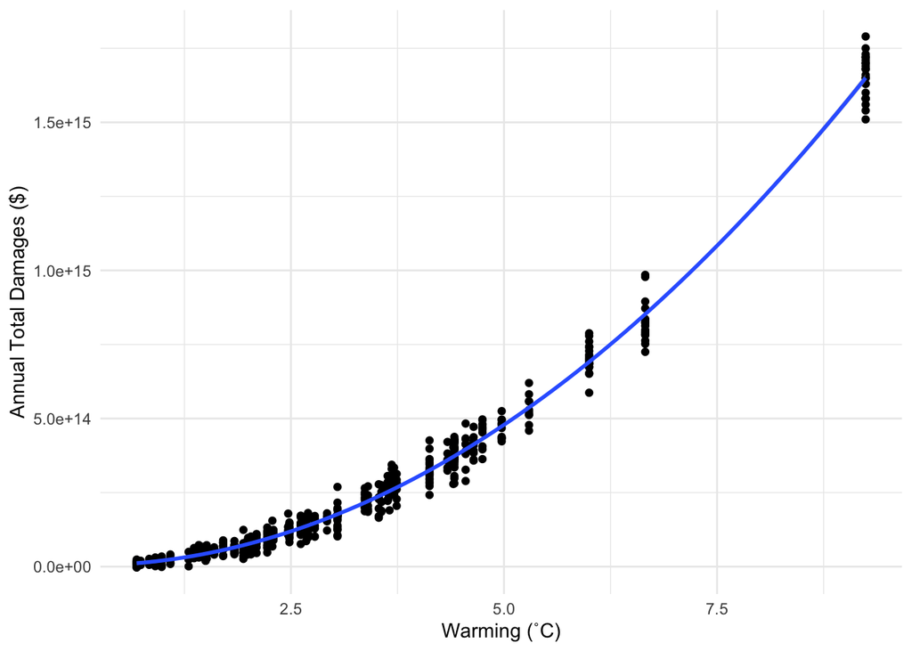

```r
ggplot(data = damages, aes(x = deg_c, y = dam)) +
  geom_point() +
  geom_smooth(method = "lm", formula = y ~ x + I(x^2)) +
  xlab("Warming (˚C)") +
  ylab("Annual Total Damages ($)") +
  theme_minimal()
```

## Question 2

```r
#using function to calculate env damage from baseline, pulse, difference, and pulse per ton of CO2
warming$base_dam <- quad_fun(warming$CO2_base,(warming$CO2_base)^2)
warming$pulse_dam <- quad_fun(warming$CO2_pulse,(warming$CO2_pulse)^2)
warming$dam_diff <- warming$pulse_dam - warming$base_dam
warming$pulse_dam_per_ton_CO2 <- warming$dam_diff/(35E9)
```

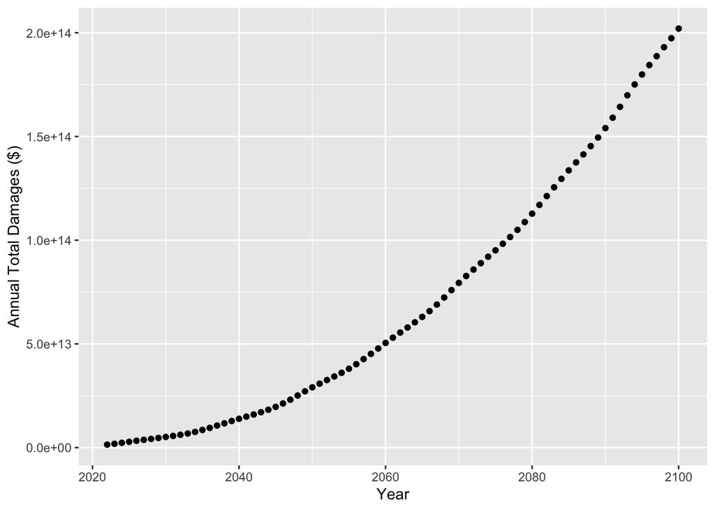

```r
ggplot(data = warming, aes(x = year, y = base_dam)) +
  geom_point() +
  xlab("Year") +
  ylab("Annual Total Damages ($)")
```

**Figure 2:** Damages over time without the pulse.

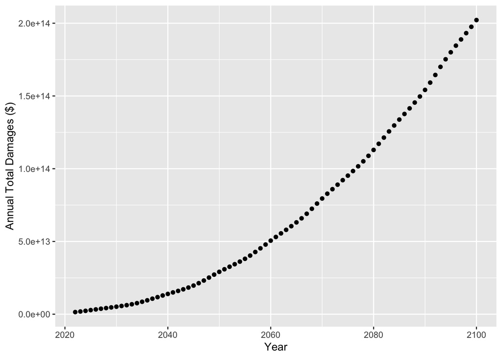

```r
ggplot(data = warming, aes(x = year, y = pulse_dam)) +
  geom_point() +
  xlab("Year") +
  ylab("Annual Total Damages ($)")
```

**Figure 3:** Damages over time with the pulse.

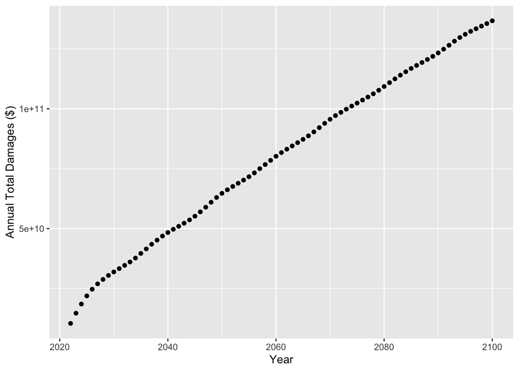

```r
ggplot(data = warming, aes(x = year, y = dam_diff)) +
  geom_point() +
  xlab("Year") +
  ylab("Annual Total Damages ($)")
```

**Figure 4:** The difference in damages over time that arises from the pulse.

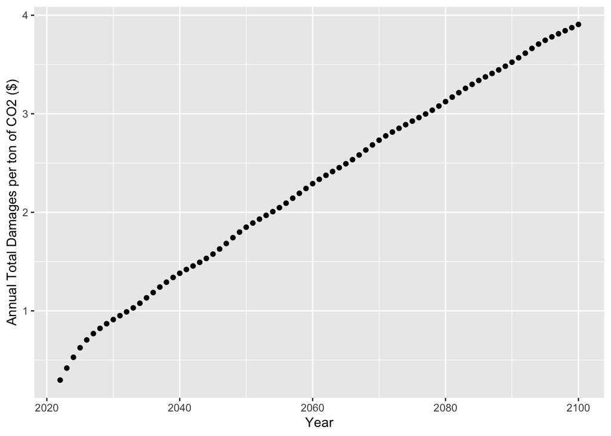

```r
ggplot(data = warming, aes(x = year, y = pulse_dam_per_ton_CO2)) +
  geom_point() +
  xlab("Year") +
  ylab("Annual Total Damages per ton of CO2 ($)")
```

**Figure 5:** The difference in damages over time from the pulse per ton of CO2 (assuming that each ton of the pulse causes the same amount of damage).

## Question 3

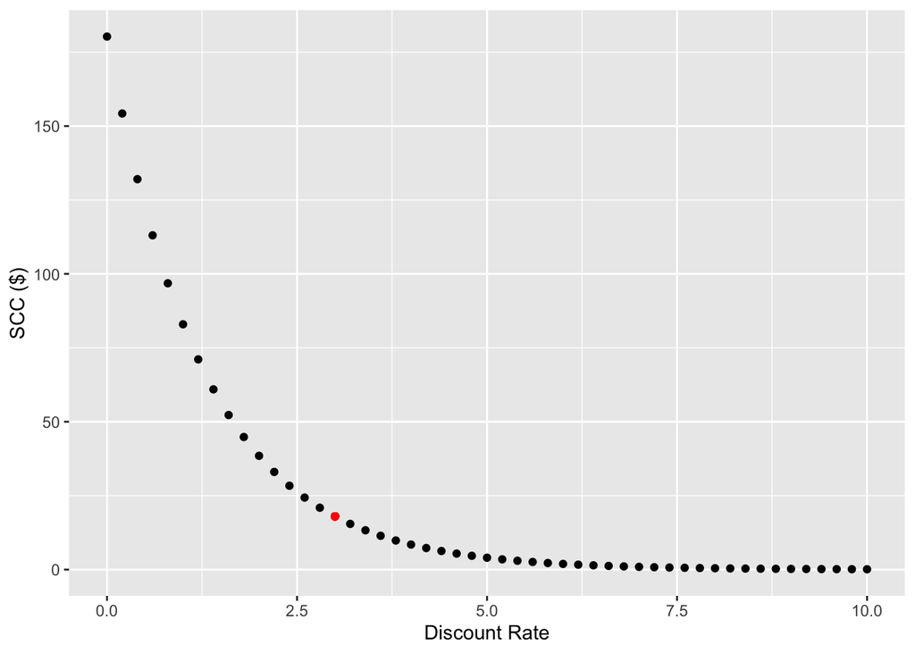

```r
one_ton_dam = sum(warming$pulse_dam_per_ton_CO2)

discount_fun <- function(rate, time, fv){
  npv <- fv/(1+(rate/100))^time
  return(npv)
}

scc_df <- data_frame(rate = seq(0,10,0.2))
scc_df$scc <- discount_fun(scc_df$rate, 78, one_ton_dam)

#q4 stuff
ramsey_rate = (.01 + (2*.01)) * 100 #multiplied by 100 to be compatible with function
discount_ramsey = discount_fun(ramsey_rate, 78, one_ton_dam)

ggplot(data = scc_df, aes(x = rate, y = scc)) +
  geom_point() +
  xlab("Discount Rate") +
  ylab("SCC ($)") +
  geom_point(aes(x = ramsey_rate, y = discount_ramsey), colour = "red")
```

**Figure 6:** The social cost of carbon (SCC) at various discount rates. A higher discount rate leads to a lower SCC. The red dot represent the SCC using the Ramsey Rule (rate = 3%).

Discount rate affects the SCC by assigning a present-day value to the cost of future damages that are a result of CO2 emissions. A lower discount rate increases the net present value of future damages which, in turn, increases the social cost of carbon. A higher discount rate leads to lower net present value for future damages which, in turn, would decrease the social cost of carbon. A low SCC most likely underestimates future damages and the discount rate is larger as a result.

## Question 4

The SCC is equal to $18 when using the Ramsey Rule to set the discount rate.

## Question 5

```r
rate_q5 = 2
#Setting Policy warming scenarios that were given
warming$policy_A_1 <- warming$CO2_base
warming$policy_A_2 <- warming$CO2_base*1.5
warming$policy_B <- warming$CO2_base

#policy B temp stays at 1.29deg C
for(i in 1:79){
  if(warming$policy_B[i] > 1.29){
    warming$policy_B[i] = 1.29
  }
}

#calculating damages
warming$policy_A_1_dam <- quad_fun(warming$policy_A_1, (warming$policy_A_1)^2)
warming$policy_A_2_dam <- quad_fun(warming$policy_A_2, (warming$policy_A_2)^2)
warming$policy_B_dam <- quad_fun(warming$policy_B, (warming$policy_B)^2)

#converting damages into NPV
warming$policy_A_1_dam_npv <- discount_fun(rate_q5, warming$year - 2022, warming$policy_A_1_dam)
warming$policy_A_2_dam_npv <- discount_fun(rate_q5, warming$year - 2022, warming$policy_A_2_dam)
warming$policy_B_dam_npv <- discount_fun(rate_q5, warming$year - 2022, warming$policy_B_dam)

#summing npv damages
A_1_sum = sum(warming$policy_A_1_dam_npv)
A_2_sum = sum(warming$policy_A_2_dam_npv)
B_sum = sum(warming$policy_B_dam_npv)

#given probabilities
A_1_prob = .5
A_2_prob = .5
A_sum = (A_1_sum * A_1_prob) + (A_2_sum * A_2_prob)

#for in text code
A_sum_trillion = A_sum/(1e12)
B_sum_trillion = B_sum/(1e12)
```

**Expected present value of damages under Policy A:** $3023 trillion  
**Expected present value of damages under Policy B:** $787 trillion

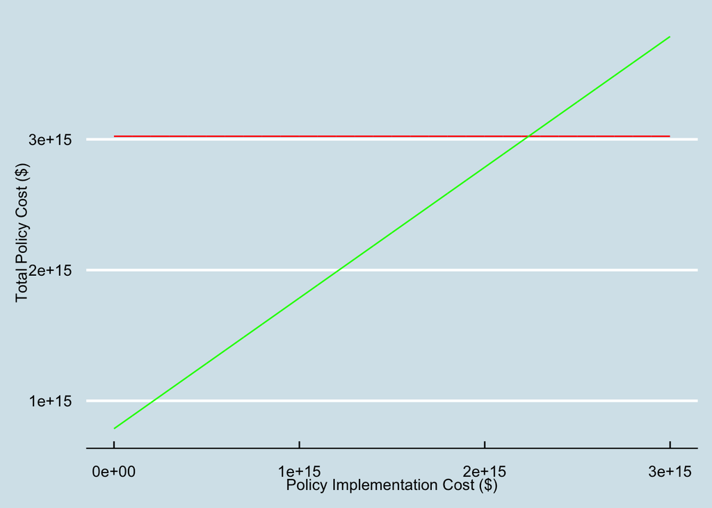

```r
#plot of cost of policies versus cost of implementation
policy_plot <- data_frame(imp_cost = seq(0,3000e12, by = 1e12))
policy_plot$pol_a <- A_sum*rep(1,length(policy_plot$imp_cost))
policy_plot$pol_b <- B_sum*rep(1,length(policy_plot$imp_cost)) + policy_plot$imp_cost

#plotting policies
ggplot(data = policy_plot) +
geom_line(aes(x = imp_cost, y = pol_a), color = "red") +
  geom_line(aes(x = imp_cost, y = pol_b), color = "green") +
  labs(x = "Policy Implementation Cost ($)", y = "Total Policy Cost ($)") +
  theme_economist()
```

```r
pol_b_slope <- lm(pol_b ~ 0 + imp_cost, data = policy_plot)$coef[1]

intersection_trill = (A_sum / pol_b_slope)/1e12
```

**Figure 7:** The red line represents the total cost of policy A that involves no implementation cost. The green line represents the total cost of policy B at different implementation costs.